# Determinant of subjective well-being

## u1817399

## Introduction

The study of subjective well-being is important, society with a high well-being drives economic productivity as individual that are more satisfied with current situations are more likely to perform well in jobs which in turns drives the economy. Understanding the determinants of subjective well-being proves critical amid of this global COVID-19 pandemic when real wage going into pre-recessions level when governments are putting in effort to lower rate of infections while protecting the economy. Therefore, with the knowledge of what affects subjective well-being and the magnitude of the effects of the factors affecting subjective well-being, allows the governments to better protect the well-being of the society which in turn for promote speedy and strong recovery of the economy.

Based on existing literature, level of health and social relationship are strong determinants for subjective well-being. As health enable the person to enjoy life without worrying about their illness, this will also apply to good mental health. Next, social relationship are strong support for high subjective well-being, as family member are able to help support each other during hard time. Furthermore, Gudmundsdottir (2013) argues that financial situations predict subjective well-being strongly, as individuals that are in a bad financial position are usually in a poor well-being.

Higher education individuals might have better opportunities for better compensations or more interesting jobs leading to a higher subjective well-being. In support of this statement, De Neve and Ward (2017) able to show that higher qualifications did have significant and beneficial effect of subjective well-being. Unemployment had constantly demonstrated lower subjective well-being for across the world (Gudmundsdottir 2013). When studying individuals in Great Britain which are unemployed around the 1990’s, they have significantly lower subjective well-being compared to individuals which are employed (Clark & Oswald 1994). Subjective well-being is usually increase as age increase (Argyle 2001).

With this in mind, we are motivated to examine the determinant of subjective well-being in current time. Based on existing literature we can identify factors affecting subjective well-being; therefore, we will examine the validity of various factors that mentioned. Among educations, financial situations, income and employment we are interested to find out the interactions among the following variables.However, fitting large variables into OLS might easily lead to a kitchen sink regression. To address the following problem, we included lasso and adaptive lasso for the analysis. Next, we will then evaluate the model with a test data set.

## Data & Methodology

Using the United Kingdom household longitudinal study (UKHLS) a cross-sectional multi-purpose survey that gathers information’s about individual’s varies socio-economic, demographic characteristics etc across the UK. Taking the latest complete dataset wave 10 of the UKHLS which conducted during 2018 till 2019. For our dependent variable we had taken “scghq1_dv” a variable measuring subjective well-being, “scghq1_dv” a scale from 0 –36 derived from asking respondents 12 questions from the General Health Questionnaire, 0 being the least distressed and 36 being the most distressed.

Next, to measure respondent’s total monthly income, we can gather respondent’s net labor income (after tax and insurance), miscellaneous income, private benefit income, investment income, pension income and social benefit income and sum it up to the variable “income” for our analysis. “j_finnow” measures respondent’s financial situation with 5 distinct categories ranging from best situations which is living comfortably, doing alright, just about getting by, finding it quite difficult to finding it very difficult, from our dataset most respondents are financially doing alright at 9691

Furthermore, by transforming the variable “j_ethn_dv” into ethnicity for our analysis which contains 6 different background which is Black, Arab, White, Mixed, Asian and Others ethnic background. To measure respondent’s marital status there are either in a partnership, separated/divorced, widowed or never married. Job status are employment, unemployed, retired or other. “j_scsf1” measures respondent’s health status from Excellent, very good, good, fair and poor.

Focusing analysis on England and cleaning the dataset, there are 24149 observations, we then split 0.75 of the observations for model building and 0.25 for testing. First, we regress “scghq1_dv” against the variables in the dataset, interested to investigate the interactions between educations, financial situations, income, and employment we include the interactions between the variables. Next, we regress the dataset with lasso and adaptive lasso.

In terms of the scale of subjective well-being 6 has highest number of respondents (2823) followed by 12 about 2639 respondent. The mean is 11 showing that on average respondent less distressed.

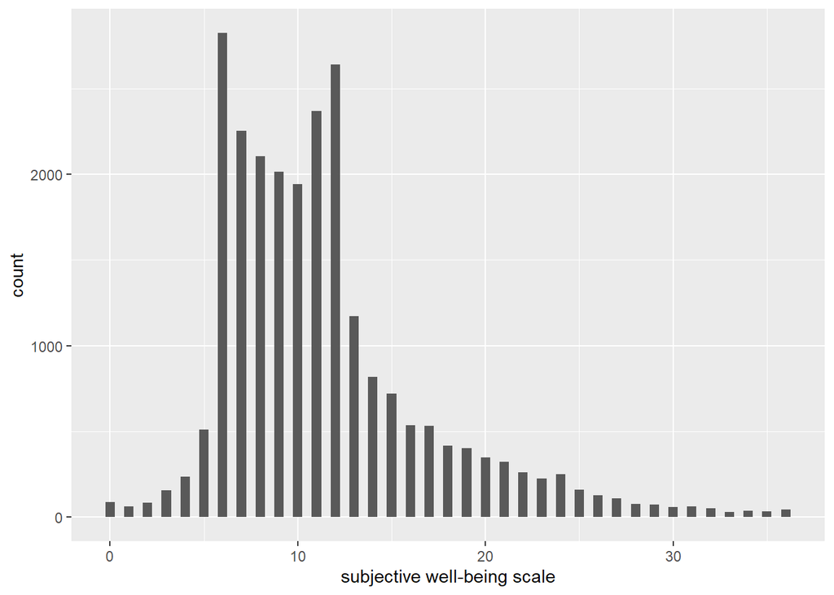

## Results

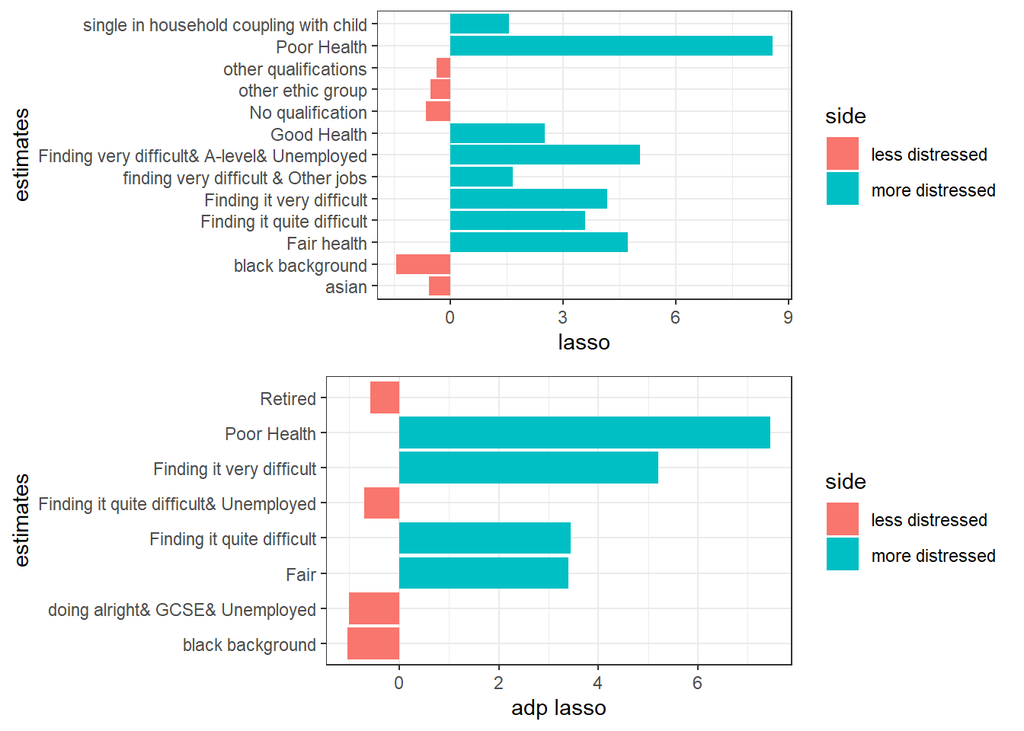

## Model Evaluation

Using our test sample to evaluate the model. Evidently lasso has the lowest mean squared error, however the adaptive lasso has the highest mean squared error among the three model. In the case of mean absolute error similarly to mean squared error lasso has the lowest value followed by the Ols model and adaptive lasso. Therefore, in the case of mean squared error and mean absolute error lasso is a slightly better model.

```
##             model mean_squared_error mean_absolute_error
## 1             ols           21.79365            3.439893
## 2           lasso           21.52097            3.426854
## 3 adapative lasso           23.05826            3.566651
```

## Conclusions

In conclusions, based on the three model, individual’s health levels and financial situations have consistently found highly significant or having strong effect indicating government need to put in resources to focus on individual’s health and financial situations in order to protect the country’s well-being.

## Appendix

# Reference

1. Argyle, M. . (2001). The psychology of happiness.Routledge., (2nd ed.)
2. Frey, B. S. and Stutzer, A. (2002). Happiness and economics: How the economy and insti-tutions affect human well-being.
3. Clark, A. E. and Oswald, A. J. (1994). Unhappiness and Unemployment.The Economic Journal, 104(424):648–659.
4. De Neve J-E, Ward G (2017) Happiness at work, Chapter 6, Helliwell et al (2017)
5. Gudmundsdottir, D. G. (2013). The impact of economic crisis on happiness.Social IndicatorsResearch, 110(3):1083–1101.